# W3cubDocs

/Matplotlib 3.1

# matplotlib.pyplot.axes

**`matplotlib.pyplot.axes(arg=None, **kwargs)` [[source]](https://matplotlib.org/3.1.1/_modules/matplotlib/pyplot.html#axes)**

Add an axes to the current figure and make it the current axes.

Call signatures:

```
plt.axes()
plt.axes(rect, projection=None, polar=False, **kwargs)
plt.axes(ax)
```

Parameters:

**`arg : { None, 4-tuple, Axes }`**

The exact behavior of this function depends on the type:

- *None*: A new full window axes is added using `subplot(111, **kwargs)`
- 4-tuple of floats *rect* = `[left, bottom, width, height]`. A new axes is added with dimensions *rect* in normalized (0, 1) units using `add_axes` on the current figure.
- `Axes`: This is equivalent to `pyplot.sca`. It sets the current axes to *arg*. Note: This implicitly changes the current figure to the parent of *arg*.

  Note

  The use of an `axes.Axes` as an argument is deprecated and will be removed in v3.0. Please use `pyplot.sca` instead.

**`projection : {None, 'aitoff', 'hammer', 'lambert', 'mollweide', 'polar', 'rectilinear', str}, optional`**

The projection type of the `Axes`. *str* is the name of a costum projection, see `projections`. The default None results in a 'rectilinear' projection.

**`polar : boolean, optional`**

If True, equivalent to projection='polar'.

**`sharex, sharey : Axes, optional`**

Share the x or y `axis` with sharex and/or sharey. The axis will have the same limits, ticks, and scale as the axis of the shared axes.

**`label : str`**

A label for the returned axes.

Returns:

**`axes : Axes (or a subclass of Axes)`**

The returned axes class depends on the projection used. It is `Axes` if rectilinear projection are used and `projections.polar.PolarAxes` if polar projection are used.

Other Parameters:

**kwargs**

This method also takes the keyword arguments for the returned axes class. The keyword arguments for the rectilinear axes class `Axes` can be found in the following table but there might also be other keyword arguments if another projection is used, see the actual axes class.

| Property | Description |
| --- | --- |
| `adjustable` | {'box', 'datalim'} |
| `agg_filter` | a filter function, which takes a (m, n, 3) float array and a dpi value, and returns a (m, n, 3) array |
| `alpha` | float |
| `anchor` | 2-tuple of floats or {'C', 'SW', 'S', 'SE', ...} |
| `animated` | bool |
| `aspect` | {'auto', 'equal'} or num |
| `autoscale_on` | bool |
| `autoscalex_on` | bool |
| `autoscaley_on` | bool |
| `axes_locator` | Callable[[Axes, Renderer], Bbox] |
| `axisbelow` | bool or 'line' |
| `clip_box` | `Bbox` |
| `clip_on` | bool |
| `clip_path` | [(`Path`, `Transform`) \| `Patch` \| None] |
| `contains` | callable |
| `facecolor` | color |
| `fc` | color |
| `figure` | `Figure` |
| `frame_on` | bool |
| `gid` | str |
| `in_layout` | bool |
| `label` | object |
| `navigate` | bool |
| `navigate_mode` | unknown |
| `path_effects` | `AbstractPathEffect` |
| `picker` | None or bool or float or callable |
| `position` | [left, bottom, width, height] or `Bbox` |
| `rasterization_zorder` | float or None |
| `rasterized` | bool or None |
| `sketch_params` | (scale: float, length: float, randomness: float) |
| `snap` | bool or None |
| `title` | str |
| `transform` | `Transform` |
| `url` | str |
| `visible` | bool |
| `xbound` | unknown |
| `xlabel` | str |
| `xlim` | (left: float, right: float) |
| `xmargin` | float greater than -0.5 |
| `xscale` | {"linear", "log", "symlog", "logit", ...} |
| `xticklabels` | List[str] |
| `xticks` | list |
| `ybound` | unknown |
| `ylabel` | str |
| `ylim` | (bottom: float, top: float) |
| `ymargin` | float greater than -0.5 |
| `yscale` | {"linear", "log", "symlog", "logit", ...} |
| `yticklabels` | List[str] |
| `yticks` | list |
| `zorder` | float |

See also

**`Figure.add_axes`**

**`pyplot.subplot`**

**`Figure.add_subplot`**

**`Figure.subplots`**

**`pyplot.subplots`**

#### Notes

If the figure already has a axes with key (*args*, *kwargs*) then it will simply make that axes current and return it. This behavior is deprecated. Meanwhile, if you do not want this behavior (i.e., you want to force the creation of a new axes), you must use a unique set of args and kwargs. The axes *label* attribute has been exposed for this purpose: if you want two axes that are otherwise identical to be added to the figure, make sure you give them unique labels.

#### Examples

```
# Creating a new full window axes
plt.axes()

# Creating a new axes with specified dimensions and some kwargs
plt.axes((left, bottom, width, height), facecolor='w')
```

## Examples using `matplotlib.pyplot.axes`

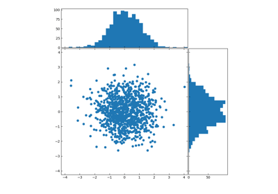

[Scatter plot with histograms](https://matplotlib.org/3.1.1/gallery/lines_bars_and_markers/scatter_hist.html#sphx-glr-gallery-lines-bars-and-markers-scatter-hist-py)

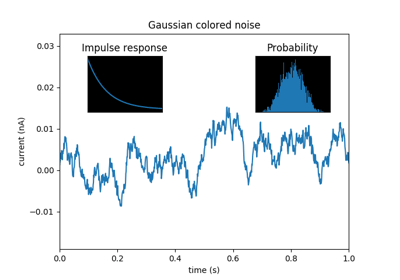

[Axes Demo](https://matplotlib.org/3.1.1/gallery/subplots_axes_and_figures/axes_demo.html#sphx-glr-gallery-subplots-axes-and-figures-axes-demo-py)

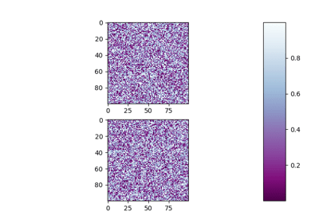

[Subplots Adjust](https://matplotlib.org/3.1.1/gallery/subplots_axes_and_figures/subplots_adjust.html#sphx-glr-gallery-subplots-axes-and-figures-subplots-adjust-py)

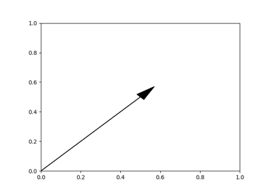

[Arrow Simple Demo](https://matplotlib.org/3.1.1/gallery/text_labels_and_annotations/arrow_simple_demo.html#sphx-glr-gallery-text-labels-and-annotations-arrow-simple-demo-py)

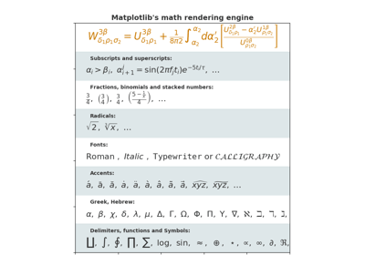

[Mathtext Examples](https://matplotlib.org/3.1.1/gallery/text_labels_and_annotations/mathtext_examples.html#sphx-glr-gallery-text-labels-and-annotations-mathtext-examples-py)

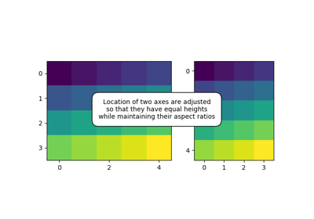

[Demo Axes Hbox Divider](https://matplotlib.org/3.1.1/gallery/axes_grid1/demo_axes_hbox_divider.html#sphx-glr-gallery-axes-grid1-demo-axes-hbox-divider-py)

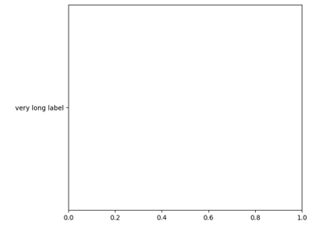

[Make Room For Ylabel Using Axesgrid](https://matplotlib.org/3.1.1/gallery/axes_grid1/make_room_for_ylabel_using_axesgrid.html#sphx-glr-gallery-axes-grid1-make-room-for-ylabel-using-axesgrid-py)

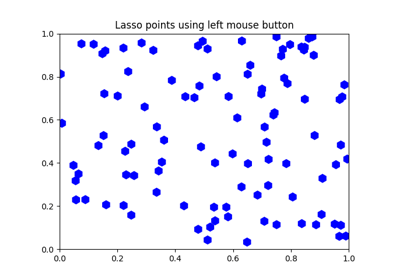

[Lasso Demo](https://matplotlib.org/3.1.1/gallery/event_handling/lasso_demo.html#sphx-glr-gallery-event-handling-lasso-demo-py)

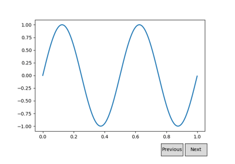

[Buttons](https://matplotlib.org/3.1.1/gallery/widgets/buttons.html#sphx-glr-gallery-widgets-buttons-py)

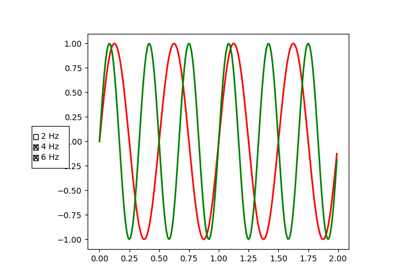

[Check Buttons](https://matplotlib.org/3.1.1/gallery/widgets/check_buttons.html#sphx-glr-gallery-widgets-check-buttons-py)

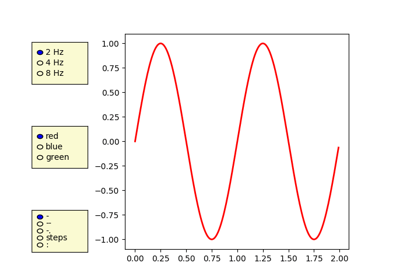

[Radio Buttons](https://matplotlib.org/3.1.1/gallery/widgets/radio_buttons.html#sphx-glr-gallery-widgets-radio-buttons-py)

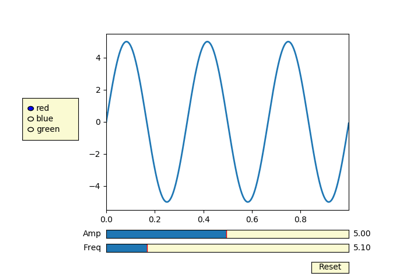

[Slider Demo](https://matplotlib.org/3.1.1/gallery/widgets/slider_demo.html#sphx-glr-gallery-widgets-slider-demo-py)

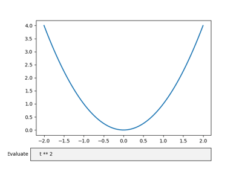

[Textbox](https://matplotlib.org/3.1.1/gallery/widgets/textbox.html#sphx-glr-gallery-widgets-textbox-py)

© 2012–2018 Matplotlib Development Team. All rights reserved.  
Licensed under the Matplotlib License Agreement.  
https://matplotlib.org/3.1.1/api/_as_gen/matplotlib.pyplot.axes.html